# An R Shiny App to Interatively Visualize Stock Price and Trade Volume

Jan 23, 2021

## Introduction

- Retrieve and process the stock data separately from the app
- User input to select a symbol and time period
- Server function:
  - Read from data saved in the same folder
  - Subset data based on the symbol and time period selected by user
  - Generate interactive plots to visual daily price, volume over time
  - Perform linear regression to explore the relationship between volume and daily price change
- Output in format of tabs:
  - Data: display the data as searchable table
  - Plot: display the plots as interactive graphs

## Load, Process and Save the Stock Data

- Retrieve stock data of five symbols from 2019-2021 using quantmod::getSymbols
- Convert the data from ts type to data.frame with addition of four variables
  - DateTime: in Date format
  - Symbol:
  - Increase: Close price > Open price ? Y/N
  - AbsDiff: Abs(Close price - Open price)
- Save to the same folder and use as source data for the app

## User Input

- Select a symbol from the selectInput gadget
- Select a time period from the sliderInput gadget

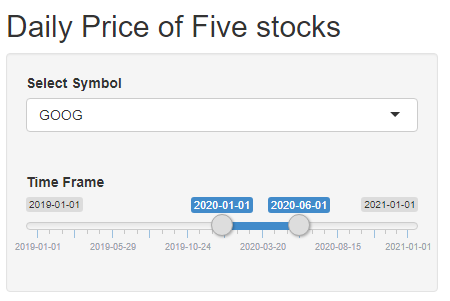

## Output (data tab): Searchable Table

- Data are displayed by renderDataTable()
- User can search and sort the data interactively

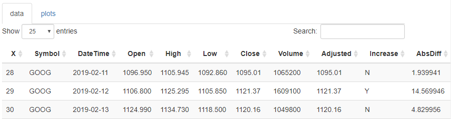

## Output (plot tab): Interative Graphs

- Plots are generated by ggplot2 and plotly and displayed by renderPlotly()
- User can see the details of each data point by hovering the mouse over the plot
- Plots:
  - Plot 1: time series of Open, Close, High and Low Price as Y-segment
  - Plot 2: time series of trade Volume
  - Plot 3: exploring the correlation between log10(Volume) and daily price change
  - Table: Statistics of linear regression of log10(volume) against Open, Close and AbsDiff(Absolute price Change)